# ms_4

## Thoughts

I feel like I pretty thoroughly explained my data in the last milestone, so I thought I would discuss in more depth the relationships I hope to investigate using this data. My vision for this project is to do an exploration of the CTDC data. As of now, I have looked at the most common origin and destination countries. I am thinking of creating a dodged bar chart of the frequencies of these countries which would give a good comparison I think. I am then going to look at the top five origin countries and looking at the characteristics of their destination countries. For example, what polity level do their destination countries have? what gdp? I have included some preliminary graphs that I have made for cambodia and the Philippines investigating their destination countries. I have yet to find any strong relationship with the polity scores, but I will continue looking. I’m also currently trying to find easy GDP data for the countries by year and not just in 2020 or 2019. I need it dating back to 2010.

## Cambodia Graph

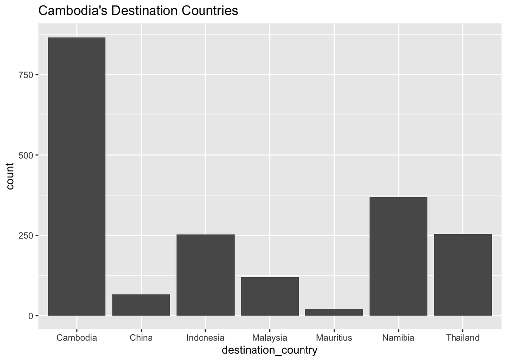

## Philippines Graph

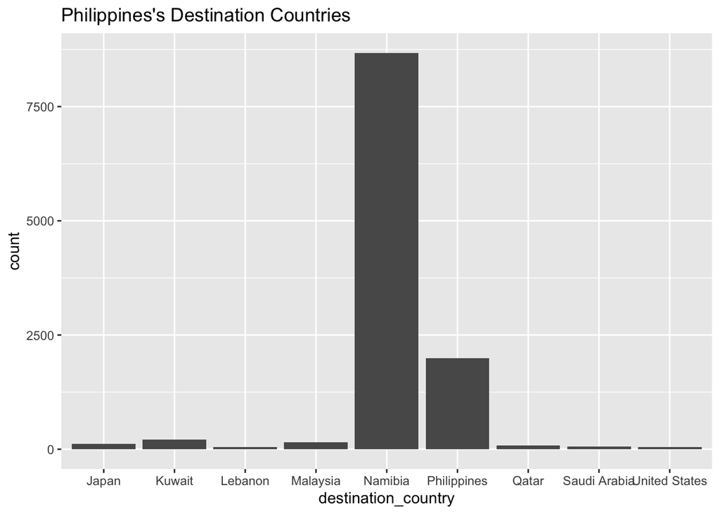